# Quantitative Paper

Lauryl Zenobi

2015-06-13

# Introduction

For the purpose of this quantitative project I will explore the theoretical frameworks associated with several key words (see below). The data derived from this exploration will be used to improve upon the background and theoretical framework of my dissertation proposal, which namely theories about analyzing ceramics, interpreting standardization of ceramic industries, and the processes that cause goods (especially staple foods) to become commodities. There is also the potential that this data will provide methodological approaches to the quantitative portion of my dissertation research, which seeks to explore the relationship between the standardization of ceramic ovens used in processing sago starch in Maluku, Indonesia, and the resulting commodification of sago in the context of the spice trade in the Banda Islands. It is useful to understand how standardization, commodification, and ceramics are discussed in the literature, in order to enrich modeling and hypothesis generation.

# Key Terms and Hypotheses

The questions that are guiding this paper consist of the following: What is the relationship between **standardization** and **ceramics** in the archaeological literature? What is the relationship between **ceramics** and **commodities**? Has the use of these terms changed over time? What theoretical frameworks and models support these types of analyses?

Due to the small sample size that is expected for these topics and study area, this project will consists of two parts. The first is a statistical analysis of the frequency of the terms identified in the preceding questions. The second part will consist of a close reading of selected articles of interest. The low numbers expected from the statistical analysis necessitate the close readings, which will be beneficial in answering higher level questions about the theoretical frameworks that were utilized in the articles of interest.

I hypothesize that standardization and ceramics will have the highest correlation, as there is a long history of looking at these topics in archaeological literature. I also suspect that commmodification and standardization will be significantly correlated. However, I do not expect to find a high degree of correlation between ceramics and commodification, as ceramics are generally utilitarian goods that were not likely to have been directly involved in luxury trade networks.

# Exploratory Data Analysis

Statistical analyses were conducted to determine the prevalence of each keyword by decade. Preliminary testing of the questions mentioned above was necessary to determine which research avenue was the most likely to produce information useful for the purpose of this study. The first task was to establish the frequency of key words that are used in the guiding research questions. **Commodity**, **Standardization**, and **Ceramics** were analyzed for their correlation over time.

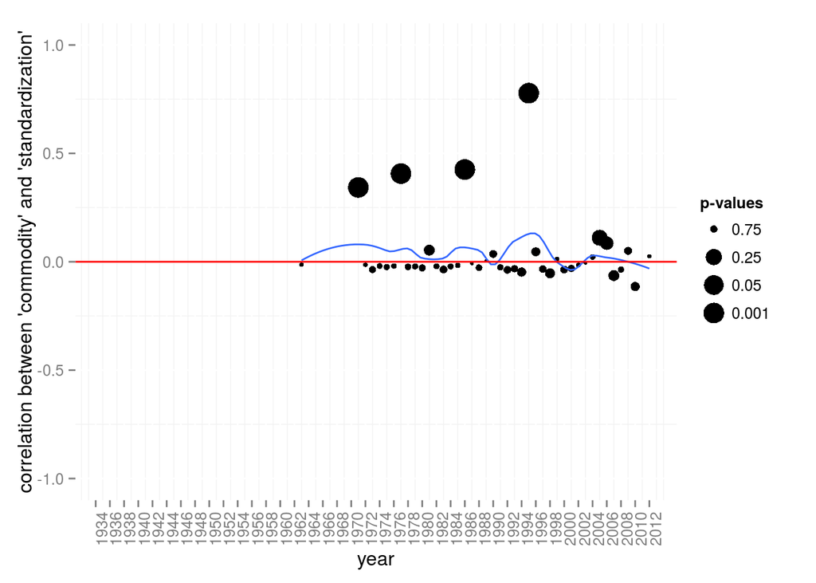

Figure 1. Correlation over time between “commodity” and “standardization”.

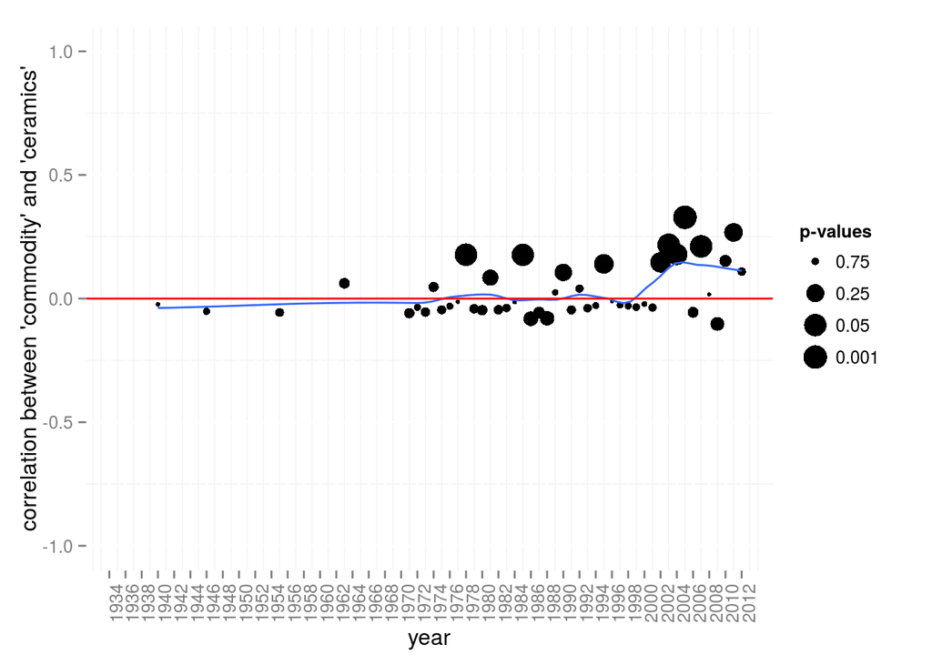

Figure 2. Correlation over time between “commodity” and “ceramics”.

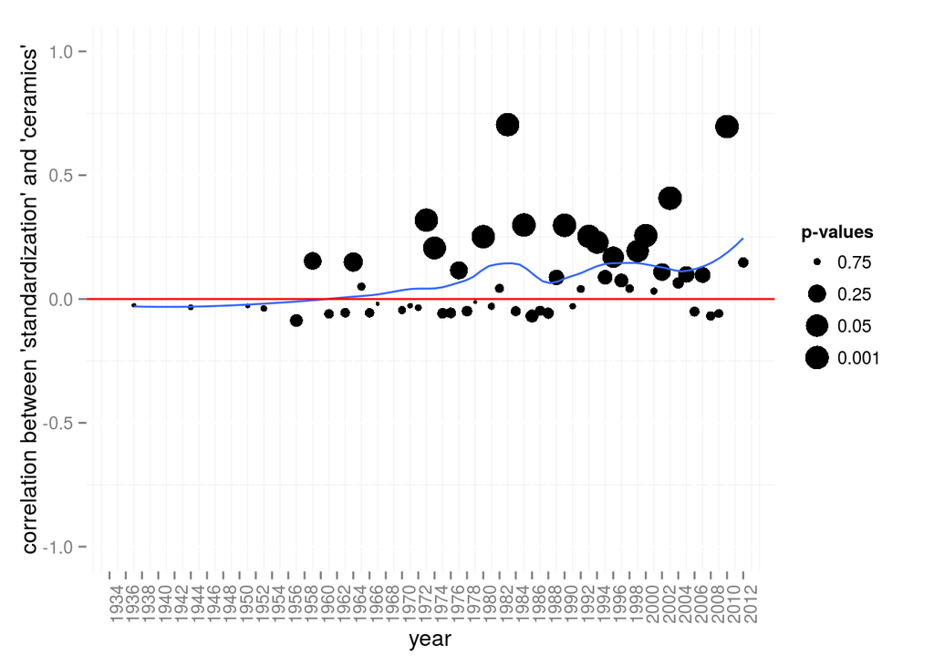

Figure 3. Correlation over time between “standardization” and “ceramics”.

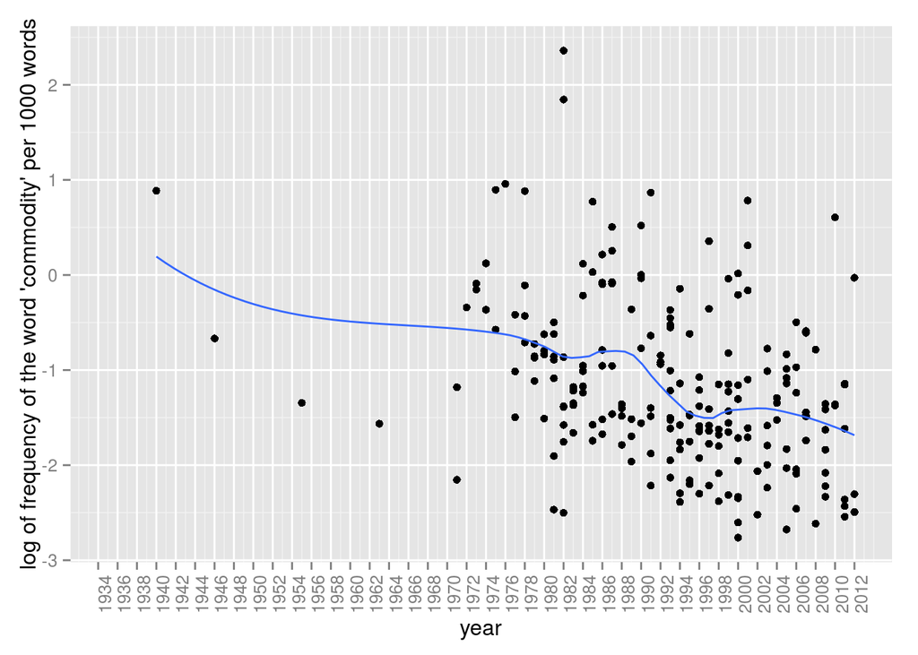

```
##    word_ratio year             V2
## 1:   10.60071 1982 10.2307_279900
```

Figure 4. Frequency of “Commodity” over time.

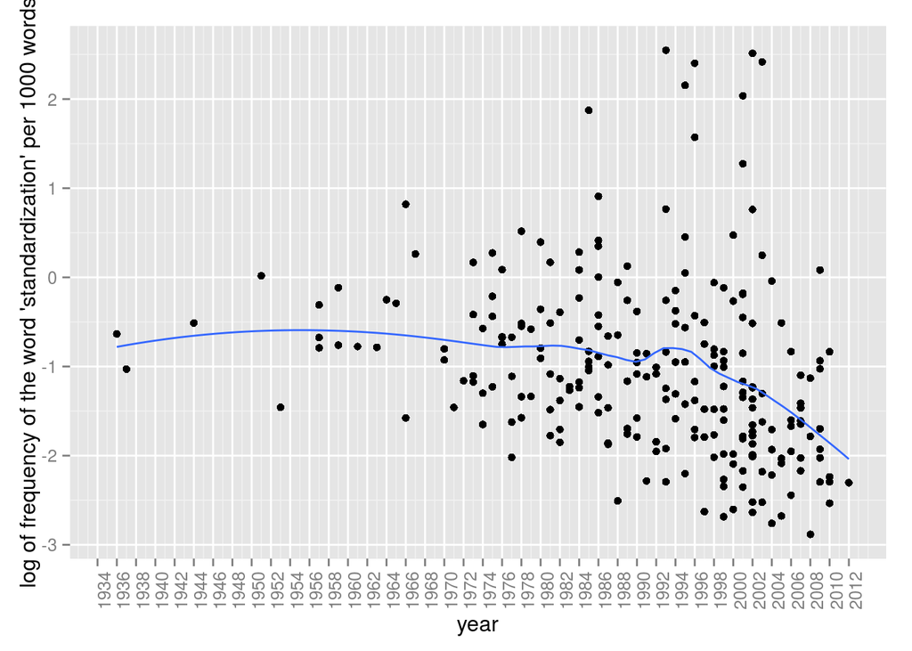

```
##    word_ratio year             V2
## 1:   12.77955 1993 10.2307_281454
```

Figure 5. Frequency of “Standardization” over time.

“Ceramics” and “ceramic” were also compared to determine which keyword would be most productive. Interestingly, the two words produced markedly different articles, with ceramics producing articles that covered a wide variety of topics related to ceramic analyses, including temper analyses and studies on the physical properties of the clay materials. The wide range of topics was not suitable for this study, which seeks to pinpoint theoretical frameworks. Therefore, “ceramic” was utilized as the keyword of interest. “Pottery” was also explored, and the results were more tailored than those of “ceramics”, however, the article with the highest proportion of the term was a response article, and not useful for exploring theoretical concepts or methods of explanation.

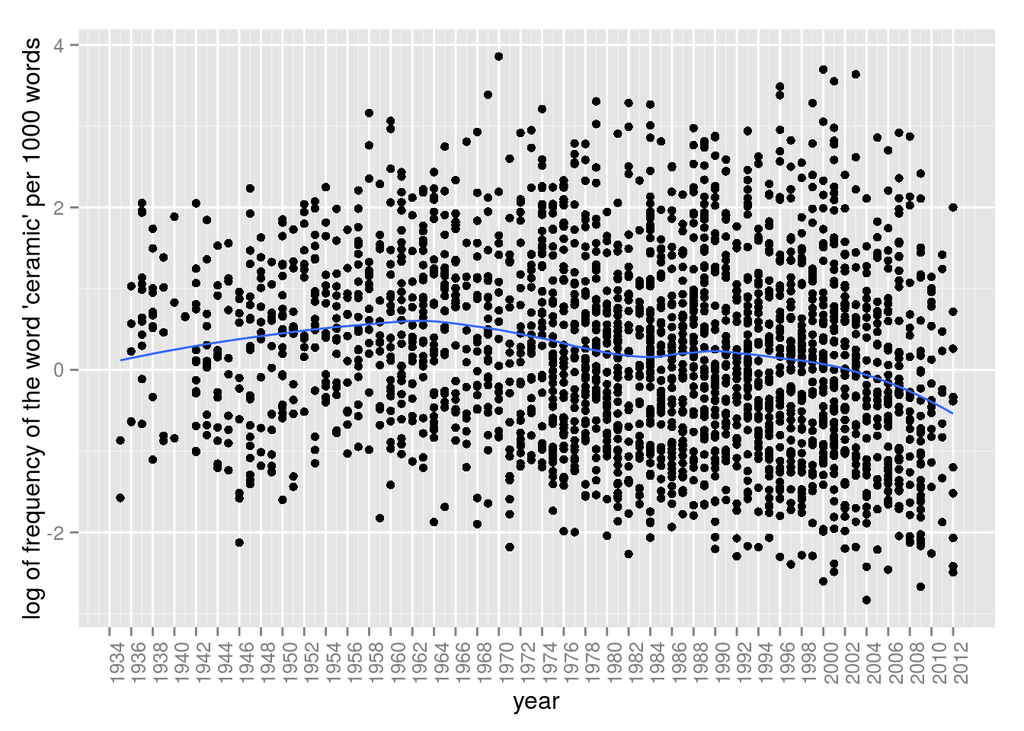

```
##    word_ratio year             V2
## 1:   47.40219 1970 10.2307_278116
```

Figure 6. Frequency of “ceramic” over time.

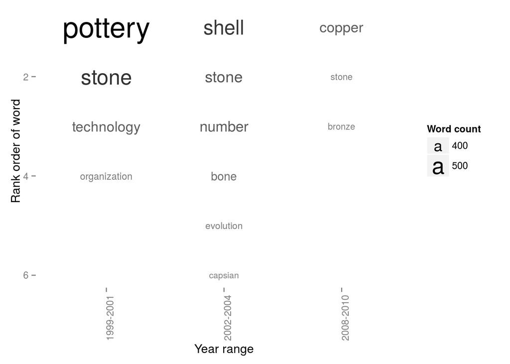

Figure 7. Words associated with “standardization” over time.

[figure not shown]

Figure 8. Words associated with “standard” over time.

It’s clear that “standard” and “standardization” produce two different frequecy plots. From 2008-2010, pottery is the fourth word most commonly printed in association with “standard”. It is also a common word during the periods of 1996-1998, the most common word associated with “standard” in the 1993-1995 literature, and the fifth most common word in articles published between 2006-2007. Standardization presents an even clearer image, in 1999-2001 article, pottery is the most common word associated with “standardization”, though it falls out of favor in later years. This demonstrates that pottery and standardization/standard regularly are associated in the literature data set.

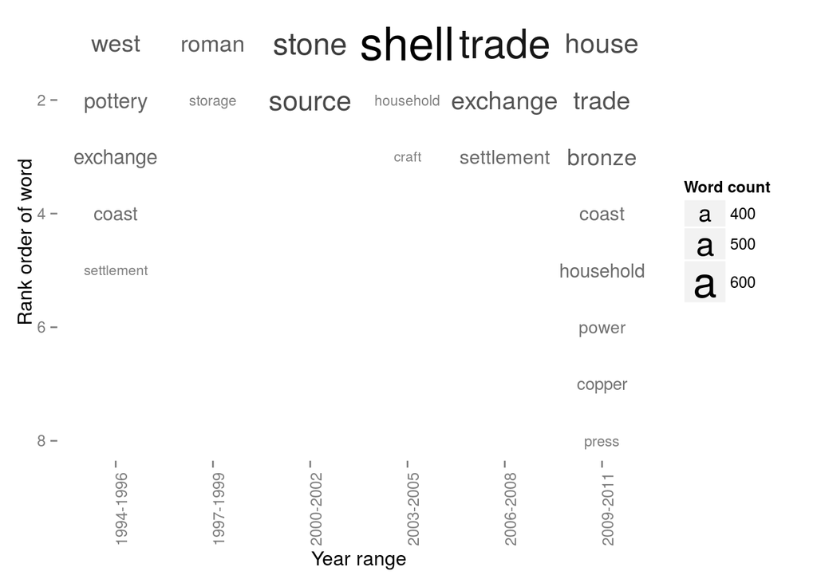

Figure 9. Words associated with “commodity” over time.

Pottery and commodity only appear in association within articles published between 1994-1996, however, during this time period, pottery is the second most common word associated with commodity, indicating the two appear at least 400 times in conjunction. Also useful for this project is the literature published between 2006-2008, in which trade and exchange are the two most commonly associated with commodity. The question that is driving this research assumes that commodities are transported as a result of increased trade and exchange, contrary to the expectations of my hypotheses.

[figure not shown]

Figure 10. Words associated with “pottery” over time.

[figure not shown]

Figures 11. Words associated with “ceramics” over time.

The results of using “pottery” show that, even taking out noisey words, the data is very jumbled. The results of a frequency analysis for “ceramics” are relatively similar, possible even more jumbled. It is interesting to note that in both cases, ceramics and pottery produce too many associations to be useful, therefore, for the purpose of the paper, standardization/standard, and commodity will be utilized because they provide much more constrained data sets and are theoretically specific.